# a3_task3

Hanna Weyland

11/3/2020

## Section 1

## Read in Urchin Data and Create a Histogram and Boxplot of Red and Purple Urchins

Here I read in the urchin data and create a histogram and box plot comparing the distribution of sizes between purple and red urchins.

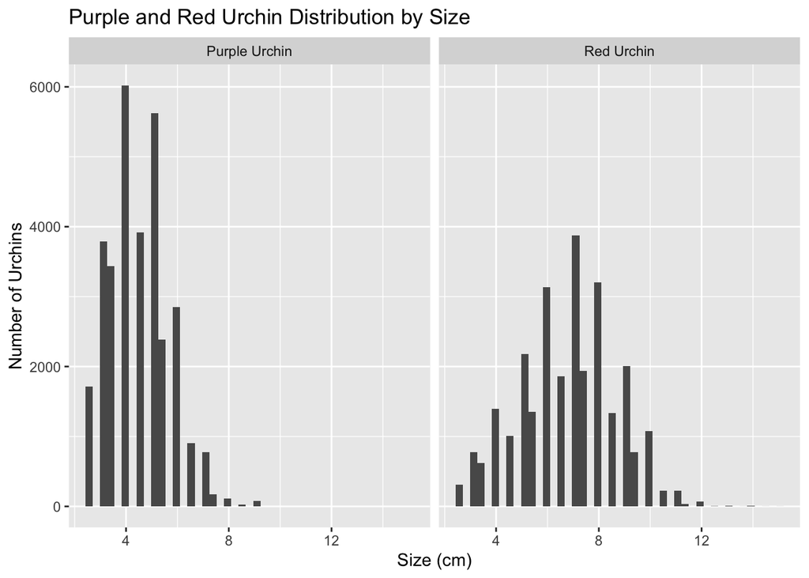

```r
urchin_data <- read.csv(here("data", "urchins.csv")) %>%
  clean_names()
ggplot(data = urchin_data, aes(x=size)) +
  geom_histogram(bins = 45) +
  facet_wrap(~common_name) +
  labs(title = "Purple and Red Urchin Distribution by Size", x = "Size (cm)", y = "Number of Urchins")
```

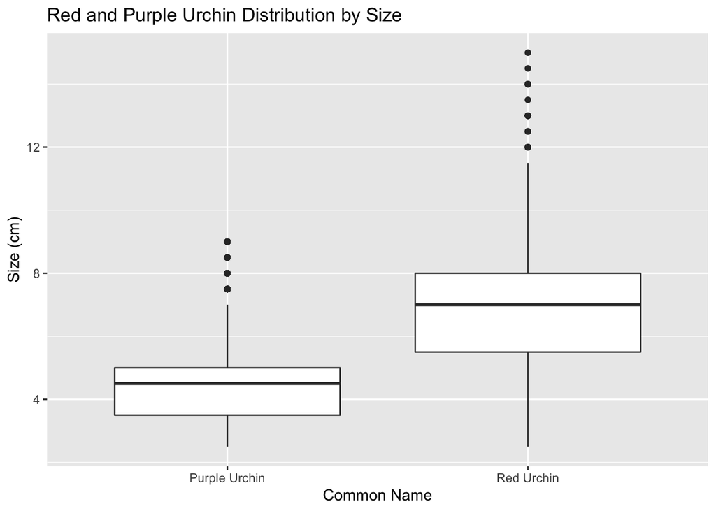

```r
ggplot(data=urchin_data, aes(x=common_name, y=size)) +
  geom_boxplot() +
  labs(title = "Red and Purple Urchin Distribution by Size", x = "Common Name", y = "Size (cm)")
```

### Summary Table for Red and Purple Urchins

Here I create a summary table for that contains the following statistics for purple and red urchins: mean, median, standard deviation, and sample size.

```r
urchin_stats <- urchin_data %>%
  group_by(common_name) %>%
  summarize(mean_size = mean(size),
            median_size = median(size),
            sd_size = sd(size),
            sample_size = n())
urchin_stats
```

```
## # A tibble: 2 x 5
##   common_name   mean_size median_size sd_size sample_size
##   <chr>             <dbl>       <dbl>   <dbl>       <int>
## 1 Purple Urchin      4.47         4.5    1.18       31805
## 2 Red Urchin         6.78         7      1.89       27408
```

> The red urchin sample has a greater distribution and a higher mean, median and standard deviation. The purple urchin sample has a smaller more condensed distribution and lower mean. The % difference between the means is 0.41 or 41%. Both samples have a relatively normal distribution although the purple urchin data looks to be slightly positively skewed.

## Section 2

### Explore Purple Urchin Counts by Site and Year

Here I look at purple urchin counts by site and year. Using the ‘case_when()’ function to change site abbreviations to full names.

```r
purple_urchins <- urchin_data %>%
  filter(common_name == "Purple Urchin") %>%
  mutate(date_new = mdy(date)) %>%
  mutate(year_new = year(date_new)) %>%
  mutate(site_full = case_when(
    site %in% c("NAPL") ~"Naples Reef",
    site %in% c("AQUE") ~"Arroyo Quemado Reef",
    site %in% c("CARP") ~"Carpinteria Reef",
    site %in% c("MOHK") ~ "Mohawk Reef",
    site %in% c("IVEE") ~ "Isla Vista Reef"
  ))
```

## Make a Summary Table

Here I will make a summary table containing the total number of purple urchins observed by site and year.

```r
purple_site_year <- purple_urchins %>%
  filter(site_full %in% c("Naples Reef", "Arroyo Quemado Reef", "Carpinteria Reef", "Mohawk Reef", "Isla Vista Reef"),
         year_new >= 2008, year_new <= 2020) %>%
  group_by(site_full, year_new) %>%
  count()
purple_site_year
```

```
## # A tibble: 61 x 3
## # Groups:   site_full, year_new [61]
##    site_full           year_new     n
##    <chr>                  <dbl> <int>
##  1 Arroyo Quemado Reef     2008    67
##  2 Arroyo Quemado Reef     2009   926
##  3 Arroyo Quemado Reef     2010   921
##  4 Arroyo Quemado Reef     2011   887
##  5 Arroyo Quemado Reef     2012   764
##  6 Arroyo Quemado Reef     2013   434
##  7 Arroyo Quemado Reef     2014   410
##  8 Arroyo Quemado Reef     2015   400
##  9 Arroyo Quemado Reef     2016   342
## 10 Arroyo Quemado Reef     2017   406
## # … with 51 more rows
```

## Create an Exploratory Graph

Here I will create a histogram displaying the counts of purple urchins recorded at each site over time for the years included in the study

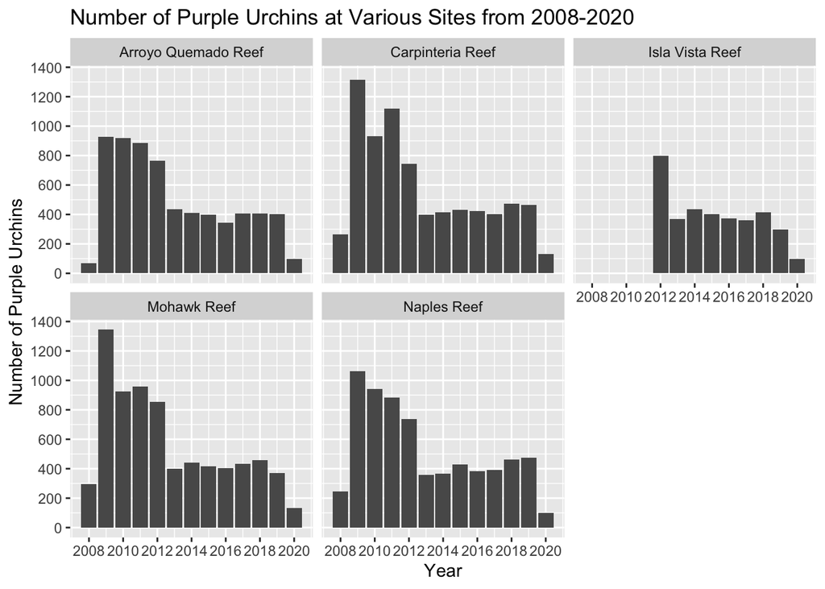

```r
ggplot(data=purple_site_year, aes(x=year_new, y=n)) +
  geom_col() +
  scale_x_continuous(breaks = scales::pretty_breaks(n = 6)) + scale_y_continuous(breaks = scales::pretty_breaks(n = 6)) +
  labs(title = "Number of Purple Urchins at Various Sites from 2008-2020", x= "Year", y="Number of Purple Urchins") +
  facet_wrap(~site_full)
```